# 24133064_NguyenThiKieuTrang_LAB4_EDA2

### 6. Scatterplot có alpha hoặc geom_bin2d() để xử lý chồng điểm.

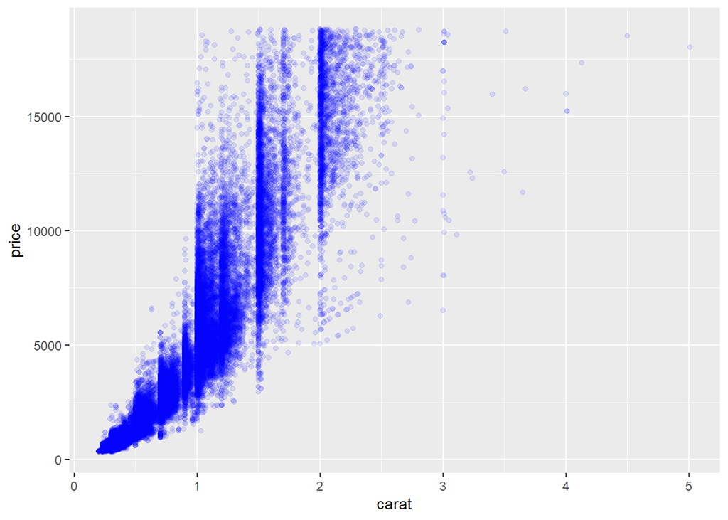

```r
ggplot(diamonds, aes(x = carat, y = price)) +
geom_point(
  color = "blue",
  alpha = 0.1
)
```

- Các điểm dữ liệu phân bố theo xu hướng tăng dần từ trái sang phải, cho thấy carat và price có tương quan dương khá rõ.
- Việc sử dụng alpha giúp biểu đồ trực quan hơn khi số lượng quan sát lớn.
- Vùng dữ liệu đậm màu tập trung chủ yếu ở khu vực carat thấp, chứng tỏ đa số kim cương trong bộ dữ liệu có kích thước nhỏ và giá không quá cao.

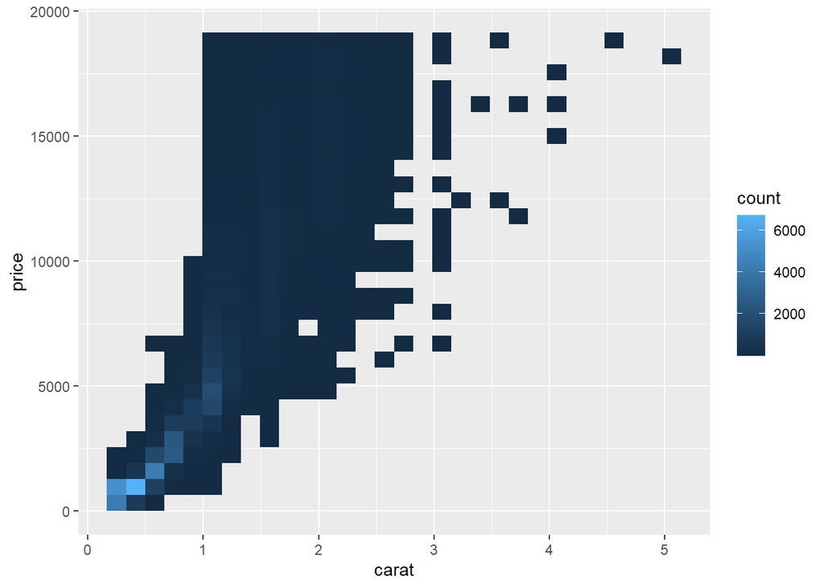

```r
ggplot(diamonds, aes(x = carat, y = price)) +
geom_bin2d()
```

### 7. Heatmap hoặc geom_count() cho quan hệ giữa cut và color

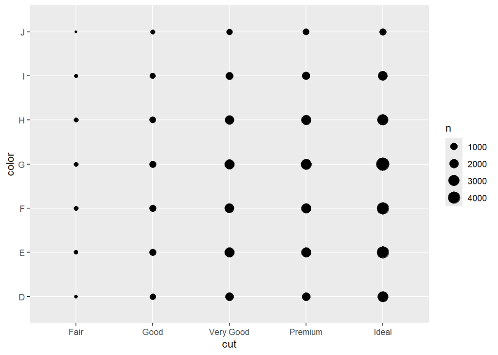

```r
ggplot(diamonds, aes(x = cut, y = color)) +
geom_count()
```

## 3. Làm sạch dữ liệu

### 1. Kiểm tra outlier ở các biến x, y, z.

```r
summary(diamonds[,c("x","y","z")])
```

```
##        x                y                z
##  Min.   : 0.000   Min.   : 0.000   Min.   : 0.000
##  1st Qu.: 4.710   1st Qu.: 4.720   1st Qu.: 2.910
##  Median : 5.700   Median : 5.710   Median : 3.530
##  Mean   : 5.731   Mean   : 5.735   Mean   : 3.539
##  3rd Qu.: 6.540   3rd Qu.: 6.540   3rd Qu.: 4.040
##  Max.   :10.740   Max.   :58.900   Max.   :31.800
```

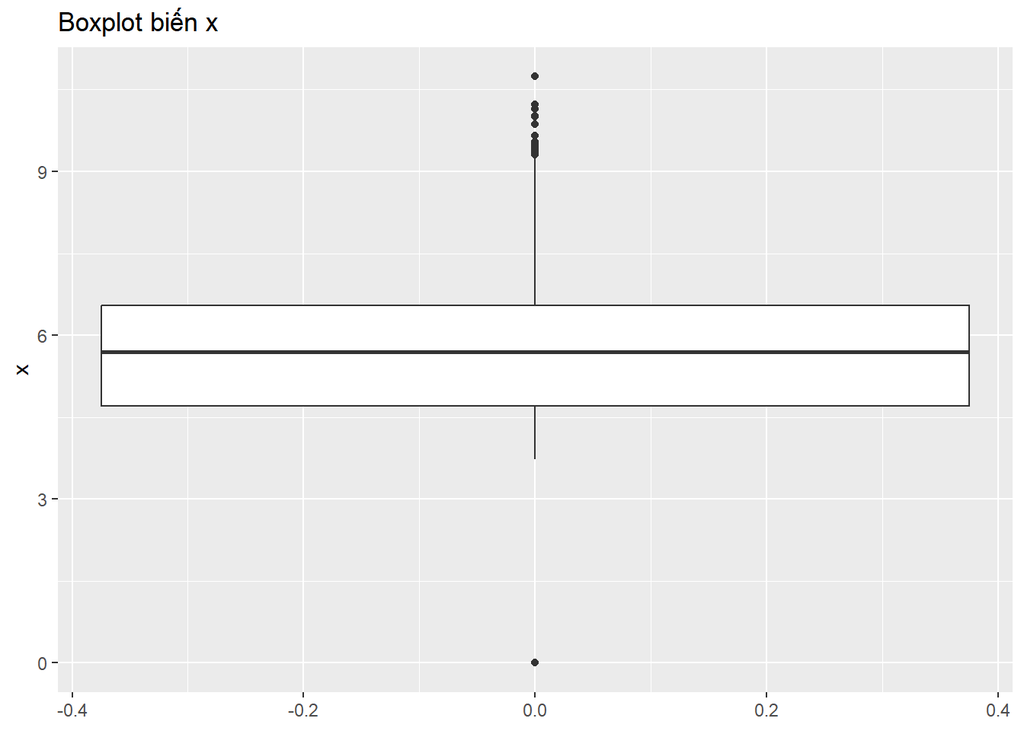

```r
ggplot(diamonds,aes(y=x))+
  geom_boxplot()+
  labs(title="Boxplot biến x")
```

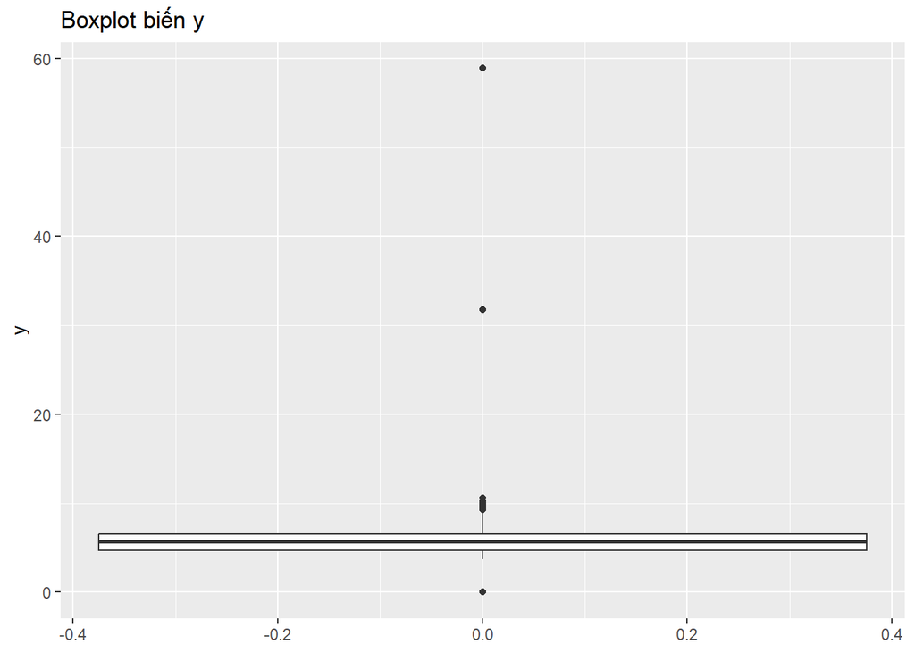

```r
ggplot(diamonds,aes(y=y))+
  geom_boxplot()+
  labs(title="Boxplot biến y")
```

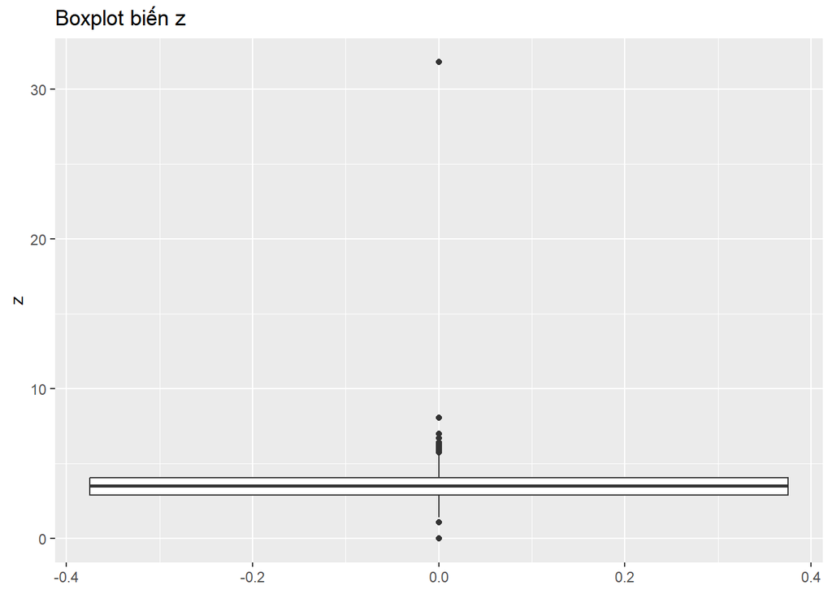

```r
ggplot(diamonds,aes(y=z))+
  geom_boxplot()+
  labs(title="Boxplot biến z")
```

Kết quả thống kê mô tả và boxplot cho thấy các biến kích thước x, y, z có xuất hiện giá trị bất thường. Một số quan sát có kích thước bằng 0 hoặc quá lớn so với phần lớn dữ liệu, có thể gây ảnh hưởng đến phân tích.

### 2. Lọc các quan sát có kích thước bất thường, ví dụ: ox == 0; y == 0; z == 0; y < 3 hoặc y > 20.

```r
outlier_size <- diamonds%>%
  filter(x==0|y==0|z==0|y<3|y>20)
nrow(outlier_size)
```

```
## [1] 22
```

Qua quá trình kiểm tra và lọc dữ liệu bằng hàm filter(), chúng ta phát hiện có 22 quan sát (viên kim cương) có kích thước bất thường (outliers).

### 3. Tạo hai phiên bản dữ liệu:

#### Phiên bản loại bỏ outlier;

```r
diamonds_remove <- diamonds %>%
  filter(!(x==0|y==0|z==0|y<3|y>20))
nrow(diamonds)
```

```
## [1] 53940
```

```r
nrow(diamonds_remove)
```

```
## [1] 53918
```

```r
diamonds_na <- diamonds %>%
  mutate(
    x=ifelse(x==0,NA,x),
    y=ifelse(y==0|y<3|y>20,NA,y),
    z=ifelse(z==0,NA,z)
  )
colSums(is.na(diamonds_na))
```

```
##   carat     cut   color clarity   depth   table   price       x       y       z
##       0       0       0       0       0       0       0       8       9      20
```

Sau khi chuyển đổi các outlier thành giá trị khuyết (NA), hệ thống đã làm sạch thành công 3 biến kích thước mà không làm thay đổi tổng số dòng của tập dữ liệu.

### 4. So sánh biểu đồ và thống kê mô tả trước/sau làm sạch.

```r
summary(diamonds[,c("x","y","z")])
```

```
##        x                y                z
##  Min.   : 0.000   Min.   : 0.000   Min.   : 0.000
##  1st Qu.: 4.710   1st Qu.: 4.720   1st Qu.: 2.910
##  Median : 5.700   Median : 5.710   Median : 3.530
##  Mean   : 5.731   Mean   : 5.735   Mean   : 3.539
##  3rd Qu.: 6.540   3rd Qu.: 6.540   3rd Qu.: 4.040
##  Max.   :10.740   Max.   :58.900   Max.   :31.800
```

```r
summary(diamonds_remove[,c("x","y","z")])
```

```
##        x                y                z
##  Min.   : 3.730   Min.   : 3.680   Min.   : 1.07
##  1st Qu.: 4.710   1st Qu.: 4.720   1st Qu.: 2.91
##  Median : 5.700   Median : 5.710   Median : 3.53
##  Mean   : 5.732   Mean   : 5.733   Mean   : 3.54
##  3rd Qu.: 6.540   3rd Qu.: 6.540   3rd Qu.: 4.04
##  Max.   :10.740   Max.   :10.540   Max.   :31.80
```

```r
summary(diamonds_na[,c("x","y","z")])
```

```
##        x                y                z
##  Min.   : 3.730   Min.   : 3.680   Min.   : 1.07
##  1st Qu.: 4.710   1st Qu.: 4.720   1st Qu.: 2.91
##  Median : 5.700   Median : 5.710   Median : 3.53
##  Mean   : 5.732   Mean   : 5.734   Mean   : 3.54
##  3rd Qu.: 6.540   3rd Qu.: 6.540   3rd Qu.: 4.04
##  Max.   :10.740   Max.   :10.540   Max.   :31.80
##  NAs    :8        NAs    :9        NAs    :20
```

Sau khi làm sạch, các giá trị bất thường như kích thước bằng 0 hoặc y quá lớn đã được xử lý. Thống kê mô tả trở nên hợp lý hơn, đặc biệt là giá trị nhỏ nhất và lớn nhất của các biến kích thước.

### 5. Giải thích lựa chọn xử lý cuối cùng.

Trong bài phân tích này, nhóm chọn phiên bản dữ liệu đã loại bỏ outlier. Lý do là các giá trị như x, y, z bằng 0 không phù hợp với thực tế vì kim cương không thể có kích thước bằng 0. Ngoài ra, các giá trị y quá nhỏ hoặc quá lớn có thể làm sai lệch biểu đồ và thống kê mô tả. Việc loại bỏ các quan sát bất thường giúp dữ liệu hợp lý hơn và kết quả phân tích đáng tin cậy hơn.

## 4. Câu hỏi:

### 1. Biến carat có quan hệ như thế nào với price?

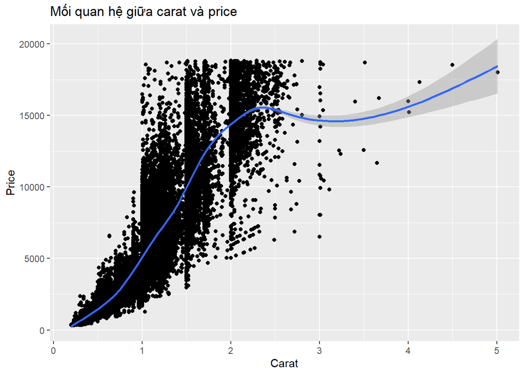

```r
ggplot(diamonds, aes(x=carat, y=price))+
  geom_point()+
  geom_smooth()+
  labs(
    title="Mối quan hệ giữa carat và price",
    x="Carat",
    y="Price"
  )
```

Biến carat và price có mối quan hệ cùng chiều. Khi carat tăng thì giá kim cương cũng có xu hướng tăng. Điều này cho thấy trọng lượng kim cương là yếu tố quan trọng ảnh hưởng đến giá.

### 2. Kim cương có cut tốt hơn có luôn đắt hơn không?

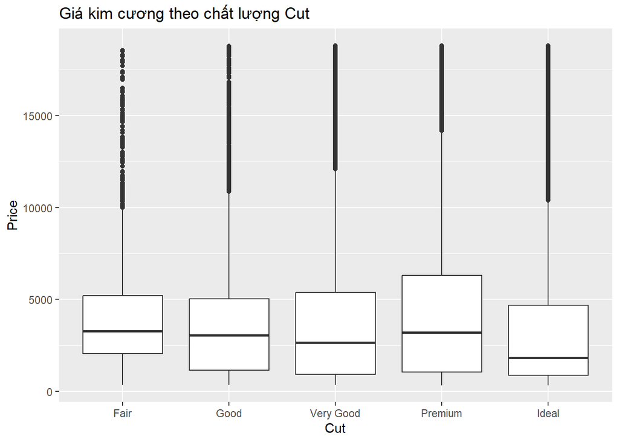

```r
ggplot(diamonds,aes(x=cut, y=price))+
  geom_boxplot()+
  labs(
    title="Giá kim cương theo chất lượng Cut",
    x="Cut",
    y="Price"
  )
```

Kim cương có cut tốt hơn không phải lúc nào cũng đắt hơn. Giá còn phụ thuộc vào nhiều yếu tố khác như carat, color và clarity. Một số nhóm cut thấp hơn vẫn có giá cao nếu viên kim cương có trọng lượng lớn.

### 3. Có outlier nào trong kích thước kim cương không?

```r
outlier_size
```

```
## # A tibble: 22 × 10
##    carat cut       color clarity depth table price     x     y     z
##    <dbl> <ord>     <ord> <ord>   <dbl> <dbl> <int> <dbl> <dbl> <dbl>
##  1  1    Premium   G     SI2      59.1    59  3142  6.55  6.48  0
##  2  1.01 Premium   H     I1       58.1    59  3167  6.66  6.6   0
##  3  1.1  Premium   G     SI2      63      59  3696  6.5   6.47  0
##  4  1.01 Premium   F     SI2      59.2    58  3837  6.5   6.47  0
##  5  1.5  Good      G     I1       64      61  4731  7.15  7.04  0
##  6  1.07 Ideal     F     SI2      61.6    56  4954  0     6.62  0
##  7  1    Very Good H     VS2      63.3    53  5139  0     0     0
##  8  1.15 Ideal     G     VS2      59.2    56  5564  6.88  6.83  0
##  9  1.14 Fair      G     VS1      57.5    67  6381  0     0     0
## 10  2    Premium   H     SI2      58.9    57 12210  8.09 58.9   8.06
## # ℹ 12 more rows
```

Có xuất hiện outlier trong kích thước kim cương, đặc biệt là các quan sát có x, y hoặc z bằng 0, hoặc biến y có giá trị quá nhỏ/quá lớn. Đây là các giá trị bất thường cần được xử lý trước khi phân tích.

### 4. Outlier ảnh hưởng thế nào đến phân tích?

Outlier có thể làm sai lệch kết quả thống kê mô tả, đặc biệt là giá trị trung bình, giá trị nhỏ nhất và lớn nhất. Ngoài ra, outlier cũng làm biểu đồ khó quan sát hơn vì trục bị kéo giãn bởi các giá trị quá lớn hoặc quá nhỏ.

5. Nếu tư vấn cho cửa hàng, nên chú ý biến nào nhất khi định giá kim cương?

```r
cor(diamonds_remove$carat, diamonds_remove$price)
```

```
## [1] 0.921586
```

## 5. Sản phẩm cần nộp:

# II. Dữ liệu mpg

## Tình huống: Phân tích hiệu quả nhiên liệu của các dòng xe. Một công ty tư vấn ô tô muốn đánh giá mức tiêu thụ nhiên liệu của các loại xe khác nhau để đưa ra khuyến nghị cho người tiêu dùng. Bộ dữ liệu mpg chứa thông tin về hãng xe, loại xe, dung tích động cơ, số xi-lanh, kiểu dẫn động và mức tiêu thụ nhiên liệu trong thành phố/đường cao tốc.

## Yêu cầu: Sinh viên đóng vai trò là chuyên viên phân tích dữ liệu trong lĩnh vực ô tô. Nhiệm vụ là thực hiện project với câu hỏi trung tâm:“Loại xe và đặc điểm kỹ thuật nào liên quan đến hiệu quả nhiên liệu?”

## 1. Phân tích dữ liệu

```r
data("mpg")
View(mpg)
head(mpg)
```

```
## # A tibble: 6 × 11
##   manufacturer model displ  year   cyl trans      drv     cty   hwy fl    class
##   <chr>        <chr> <dbl> <int> <int> <chr>      <chr> <int> <int> <chr> <chr>
## 1 audi         a4      1.8  1999     4 auto(l5)   f        18    29 p     compa…
## 2 audi         a4      1.8  1999     4 manual(m5) f        21    29 p     compa…
## 3 audi         a4      2    2008     4 manual(m6) f        20    31 p     compa…
## 4 audi         a4      2    2008     4 auto(av)   f        21    30 p     compa…
## 5 audi         a4      2.8  1999     6 auto(l5)   f        16    26 p     compa…
## 6 audi         a4      2.8  1999     6 manual(m5) f        18    26 p     compa…
```

### 1. Mô tả cấu trúc dữ liệu mpg.

#### Số dòng

```r
nrow(mpg)
```

```
## [1] 234
```

#### Số cột

```r
ncol(mpg)
```

```
## [1] 11
```

#### Kiểu dữ liệu

```r
str(mpg)
```

```
## tibble [234 × 11] (S3: tbl_df/tbl/data.frame)
##  $ manufacturer: chr [1:234] "audi" "audi" "audi" "audi" ...
##  $ model       : chr [1:234] "a4" "a4" "a4" "a4" ...
##  $ displ       : num [1:234] 1.8 1.8 2 2 2.8 2.8 3.1 1.8 1.8 2 ...
##  $ year        : int [1:234] 1999 1999 2008 2008 1999 1999 2008 1999 1999 2008 ...
##  $ cyl         : int [1:234] 4 4 4 4 6 6 6 4 4 4 ...
##  $ trans       : chr [1:234] "auto(l5)" "manual(m5)" "manual(m6)" "auto(av)" ...
##  $ drv         : chr [1:234] "f" "f" "f" "f" ...
##  $ cty         : int [1:234] 18 21 20 21 16 18 18 18 16 20 ...
##  $ hwy         : int [1:234] 29 29 31 30 26 26 27 26 25 28 ...
##  $ fl          : chr [1:234] "p" "p" "p" "p" ...
##  $ class       : chr [1:234] "compact" "compact" "compact" "compact" ...
```

Bộ dữ liệu mpg gồm nhiều biến định tính và định lượng dùng để mô tả đặc điểm xe và mức tiêu thụ nhiên liệu.

### 2. Phân loại biến:

#### biến phân loại: manufacturer, model, class, drv, fl, trans;

```r
categortical_vars <- c("manufacturer", "model", "class", "drv","fl","trans")
categortical_vars
```

```
## [1] "manufacturer" "model"        "class"        "drv"          "fl"
## [6] "trans"
```

#### biến định lượng: displ, year, cyl, cty, hwy.

```r
continous_vars <- c("displ", "year", "cyl", "cty","hwy")
continous_vars
```

```
## [1] "displ" "year"  "cyl"   "cty"   "hwy"
```

### 3. Tính thống kê mô tả cho cty, hwy, displ.

```r
summary(mpg[,c("cty","hwy","displ")])
```

```
##       cty             hwy            displ
##  Min.   : 9.00   Min.   :12.00   Min.   :1.600
##  1st Qu.:14.00   1st Qu.:18.00   1st Qu.:2.400
##  Median :17.00   Median :24.00   Median :3.300
##  Mean   :16.86   Mean   :23.44   Mean   :3.472
##  3rd Qu.:19.00   3rd Qu.:27.00   3rd Qu.:4.600
##  Max.   :35.00   Max.   :44.00   Max.   :7.000
```

Dữ liệu cho thấy mức tiêu thụ nhiên liệu và dung tích động cơ có độ phân tán tương đối lớn giữa các loại xe.

### 4. Tạo bảng tóm tắt hwy theo class.

```r
mpg %>%
  group_by(class)%>%
  summarise(
    mean_hwy=mean(hwy),
    min_hwy=min(hwy),
    max_hwy=max(hwy)
  )
```

```
## # A tibble: 7 × 4
##   class      mean_hwy min_hwy max_hwy
##   <chr>         <dbl>   <int>   <int>
## 1 2seater        24.8      23      26
## 2 compact        28.3      23      44
## 3 midsize        27.3      23      32
## 4 minivan        22.4      17      24
## 5 pickup         16.9      12      22
## 6 subcompact     28.1      20      44
## 7 suv            18.1      12      27
```

### 5. Tạo bảng tóm tắt hwy theo drv.

```r
mpg %>%
  group_by(drv)%>%
  summarise(
    mean_hwy=mean(hwy),
    min_hwy=min(hwy),
    max_hwy=max(hwy)
  )
```

```
## # A tibble: 3 × 4
##   drv   mean_hwy min_hwy max_hwy
##   <chr>    <dbl>   <int>   <int>
## 1 4         19.2      12      28
## 2 f         28.2      17      44
## 3 r         21        15      26
```

### 6. Đặt ít nhất 5 câu hỏi EDA.

#### 1.Loại xe nào có hwy cao nhất?

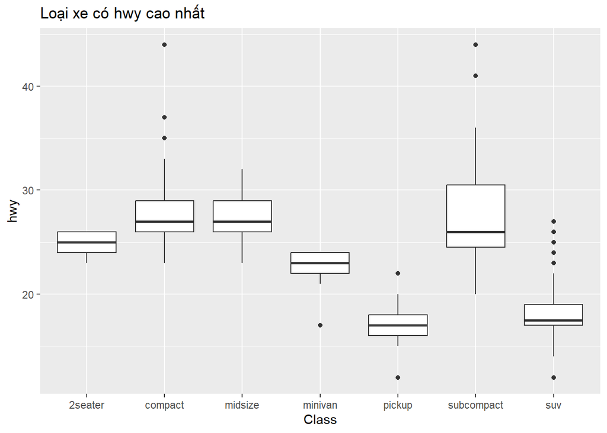

```r
ggplot(mpg, aes(x=class, y=hwy))+
  geom_boxplot()+
  labs(
    title="Loại xe có hwy cao nhất",
    x="Class",
    y="hwy"
  )
```

Loại xe Compact (xe cỡ nhỏ) và Subcompact (xe bình dân cỡ nhỏ) có hwy cao nhất (tiết kiệm xăng nhất). Ngược lại, xe Pickup (xe bán tải) và SUV có hwy thấp nhất.

#### 2.Xe có dung tích động cơ lớn có tiêu hao nhiên liệu nhiều hơn không?

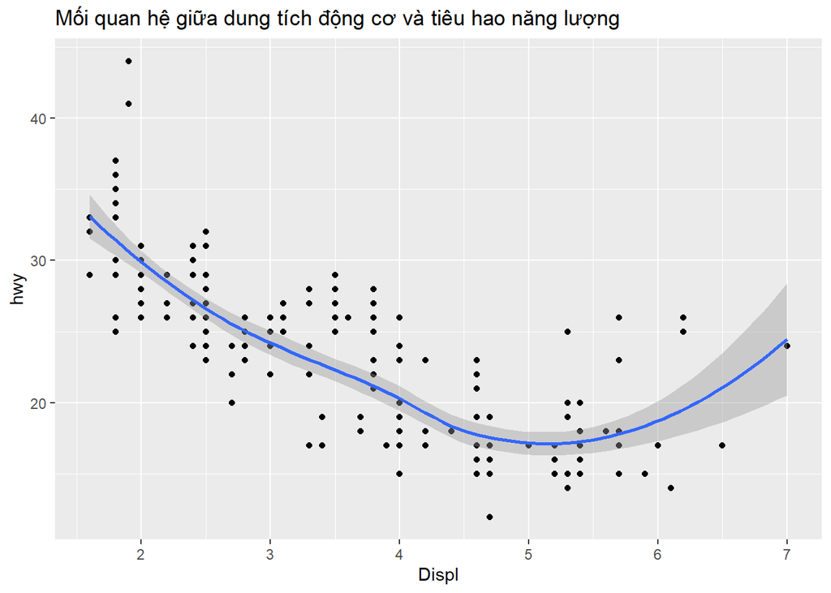

```r
ggplot(mpg, aes(x=displ,y=hwy))+
  geom_point()+
  geom_smooth()+
  labs(
    title="Mối quan hệ giữa dung tích động cơ và tiêu hao năng lượng",
    x="Displ",
    y="hwy"
  )
```

Nhìn vào đường xu hướng màu xanh, khi dung tích động cơ (Displ) tăng từ 2 lên 5 lít, chỉ số hwy giảm mạnh từ trên 30 xuống dưới 20. Chỉ số hwy thấp nghĩa là xe chạy được ít dặm hơn trên một đơn vị xăng, chứng tỏ xe tốn xăng hơn (tiêu hao nhiên liệu nhiều hơn).

#### 3.Dẫn động nào tiết kiệm nhiên liệu nhất?

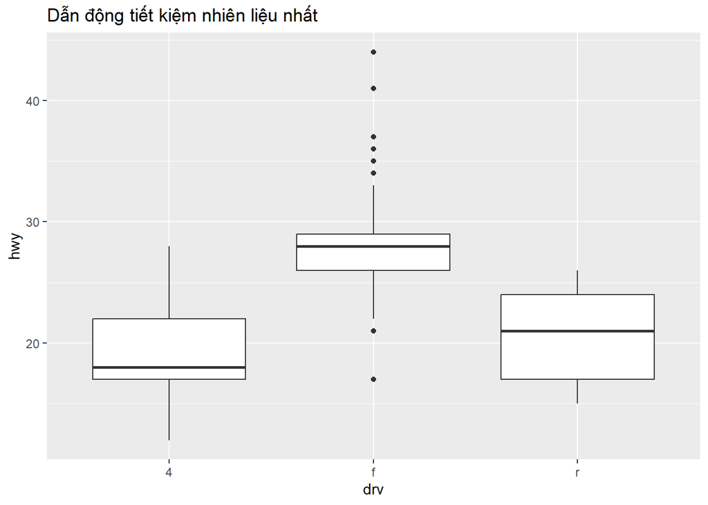

```r
ggplot(mpg, aes(x=drv, y=hwy))+
  geom_boxplot()+
  labs(
    title="Dẫn động tiết kiệm nhiên liệu nhất",
    x="drv",
    y="hwy"
  )
```

Dẫn động cầu trước (f - front-wheel drive) là tiết kiệm nhiên liệu nhất (hộp biểu đồ của f nằm cao nhất trên trục hwy). Dẫn động 4 bánh (4) và cầu sau (r) tốn xăng hơn.

#### 4.Loại xe nào phổ biến nhất?

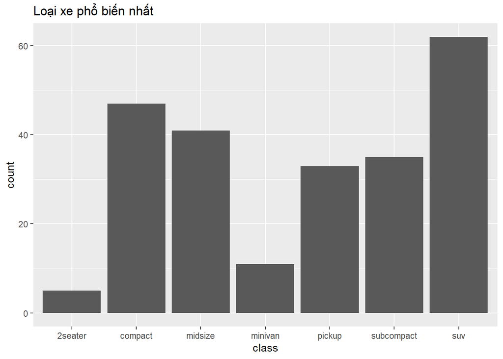

```r
ggplot(mpg, aes(x=class))+
  geom_bar()+
  labs(
    title="Loại xe phổ biến nhất",
  )
```

Loại xe phổ biến nhất là SUV, theo sau đó là hai dòng Compact và Midsize.

#### 5.Có mối quan hệ giữa displ và hwy không?

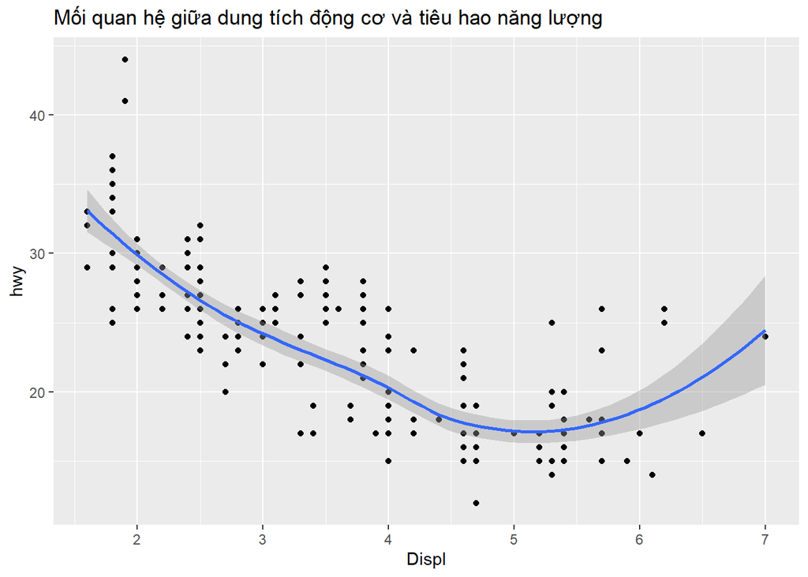

```r
ggplot(mpg, aes(x=displ,y=hwy))+
  geom_point()+
  geom_smooth()+
  labs(
    title="Mối quan hệ giữa dung tích động cơ và tiêu hao năng lượng",
    x="Displ",
    y="hwy"
  )
```

```r
cor(mpg$displ, mpg$hwy)
```

```
## [1] -0.76602
```

## 2. Trực quan hóa dữ liệu

### 1. Bar chart số lượng xe theo class.

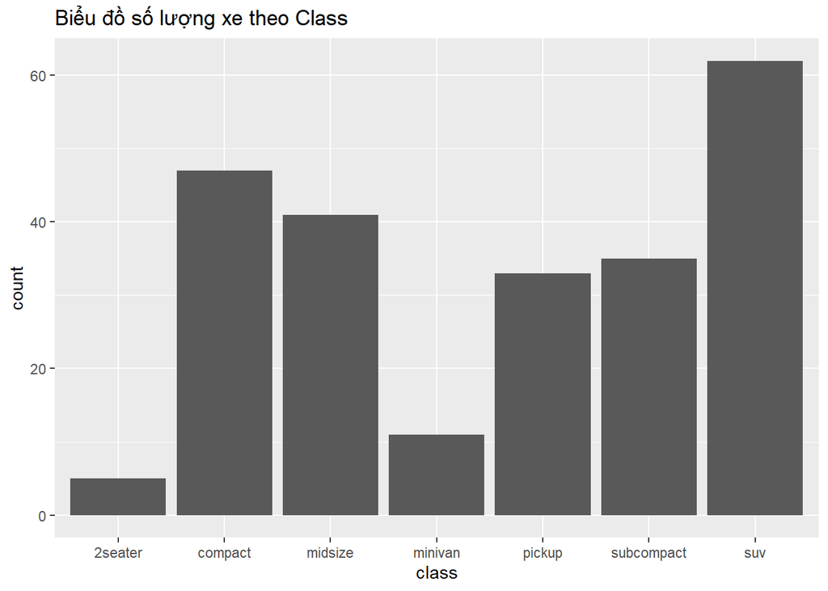

```r
ggplot(mpg, aes(x=class))+
  geom_bar()+
  labs(
    title="Biểu đồ số lượng xe theo Class"
  )
```

Loại xe phổ biến nhất là SUV, theo sau đó là hai dòng Compact và Midsize. Loại ít phổ biến nhất là 2seater.

### 2. Boxplot hwy theo class.

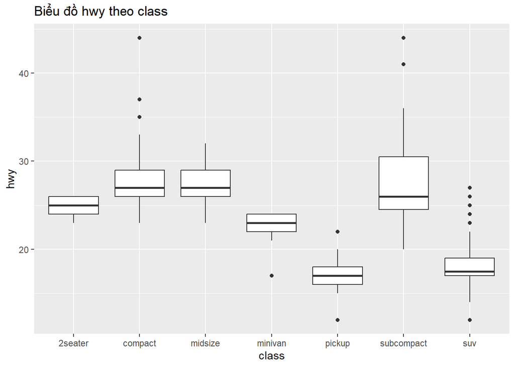

```r
ggplot(mpg, aes(x=class, y=hwy))+
  geom_boxplot()+
  labs(
    title="Biểu đồ hwy theo class"
  )
```

Loại xe có chỉ số hwy cao nhất (tiết kiệm nhiên liệu nhất) là subcompact và compact. Loại xe có chỉ số hwy thấp nhất (tốn nhiên liệu nhất) là pickup và suv. Biểu đồ hộp cho thấy kích thước xe có ảnh hưởng rõ rệt đến mức tiêu hao nhiên liệu. Xe càng nhỏ gọn thì càng chạy được nhiều dặm trên một gallon xăng và ngược lại.

### 3. Boxplot cty theo class.

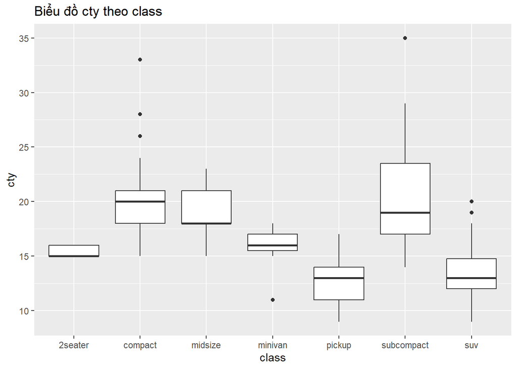

```r
ggplot(mpg, aes(x=class, y=cty))+
  geom_boxplot()+
  labs(
    title="Biểu đồ cty theo class"
  )
```

Loại xe có chỉ số cty cao nhất (tiết kiệm nhất trong thành phố) là subcompact, và thấp nhất (tốn xăng nhất) là pickup. So với biểu đồ đường trường (hwy), chỉ số tiêu hao nhiên liệu trong thành phố (cty) của tất cả các dòng xe đều thấp hơn rõ rệt. Điều này hoàn toàn phù hợp với thực tế do điều kiện giao thông đô thị thường xuyên gây hao tốn nhiên liệu hơn.

### 4. Boxplot hwy theo drv.

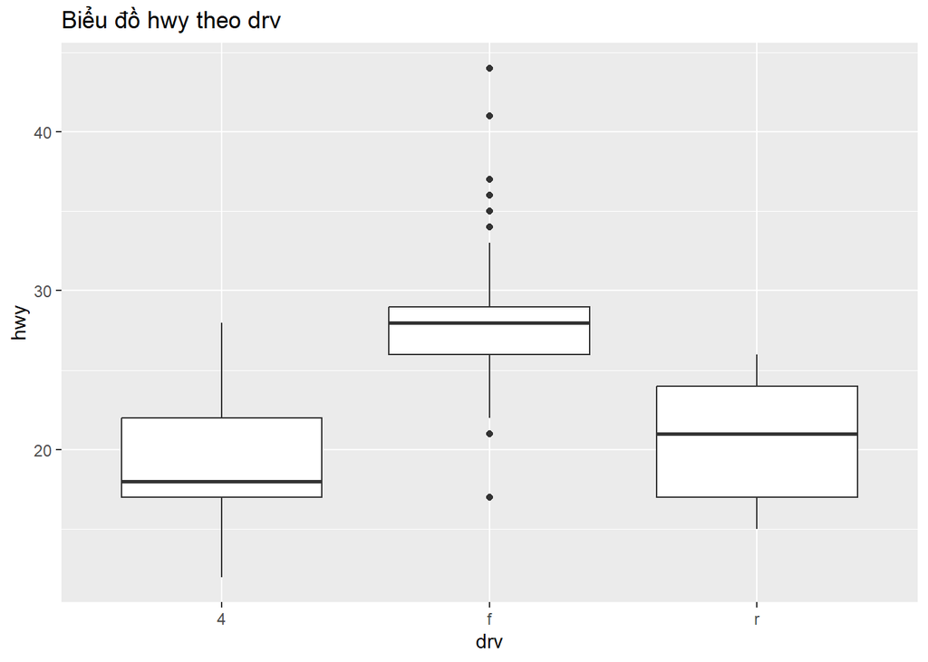

```r
ggplot(mpg, aes(x=drv, y=hwy))+
  geom_boxplot()+
  labs(
    title="Biểu đồ hwy theo drv"
  )
```

Xe dẫn động cầu trước (f) có chỉ số hwy cao nhất, tức là tiết kiệm nhiên liệu nhất. Xe dẫn động 4 bánh (4) có chỉ số hwy thấp nhất, tức là tiêu hao nhiên liệu nhiều nhất. Hệ thống dẫn động có ảnh hưởng rõ rệt đến mức tiêu hao xăng. Xe cầu trước (f) tối ưu lượng xăng tốt nhất so với xe cầu sau (r) và xe 2 cầu (4).

### 5. Scatterplot giữa displ và hwy.

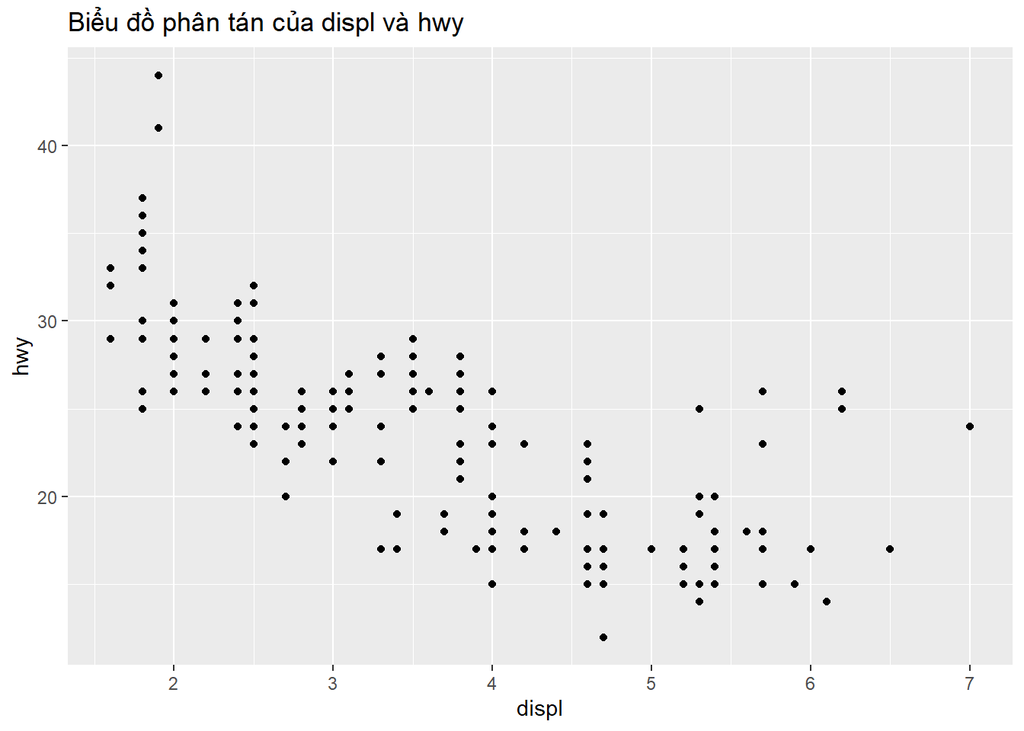

```r
ggplot(mpg, aes(x=displ, y=hwy))+
  geom_point()+
  labs(
    title="Biểu đồ phân tán của displ và hwy",
    x="displ",
    y="hwy"
  )
```

Các chấm tròn đen (hwy) có xu hướng đi xuống theo chiều tăng của displ nên hai đại lượng này tỷ lệ nghịch với nhau - động cơ càng to thì càng tốn xăng.

### 6. Scatterplot giữa displ và cty.

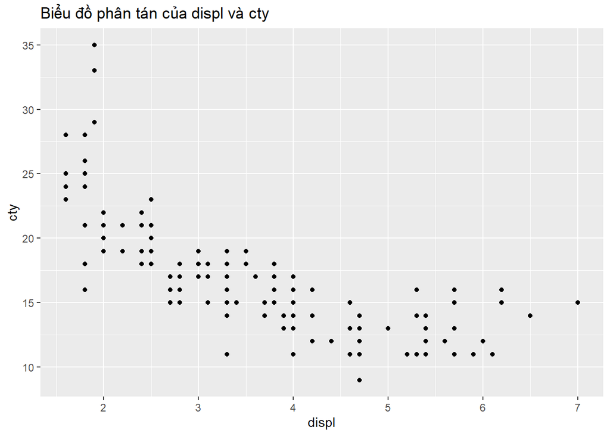

```r
ggplot(mpg, aes(x=displ, y=cty))+
  geom_point()+
  labs(
    title="Biểu đồ phân tán của displ và cty",
    x="displ",
    y="cty"
  )
```

Các chấm tròn đen (cty) có xu hướng đi xuống theo chiều tăng của displ nên hai đại lượng này tỷ lệ nghịch với nhau - chạy trong thành phố thì động cơ càng to cũng càng tốn xăng.

### 7. Scatterplot displ – hwy, tô màu theo class.

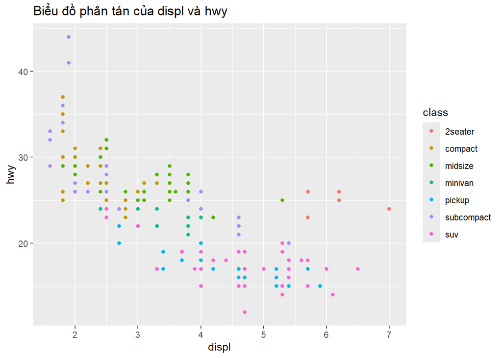

```r
ggplot(mpg, aes(x=displ, y=hwy, color=class))+
  geom_point()+
  labs(
    title="Biểu đồ phân tán của displ và hwy",
    x="displ",
    y="hwy"
  )
```

Biểu đồ cho thấy sự phân cụm rõ rệt theo loại xe. Xe nhóm compact và subcompact (màu vàng, tím) tập trung ở vùng động cơ nhỏ và rất tiết kiệm xăng. Ngược lại, xe nhóm suv và pickup (màu hồng, xanh dương) tập trung ở vùng động cơ lớn và tiêu hao nhiên liệu nhiều.

### 8. Facet theo drv hoặc class.

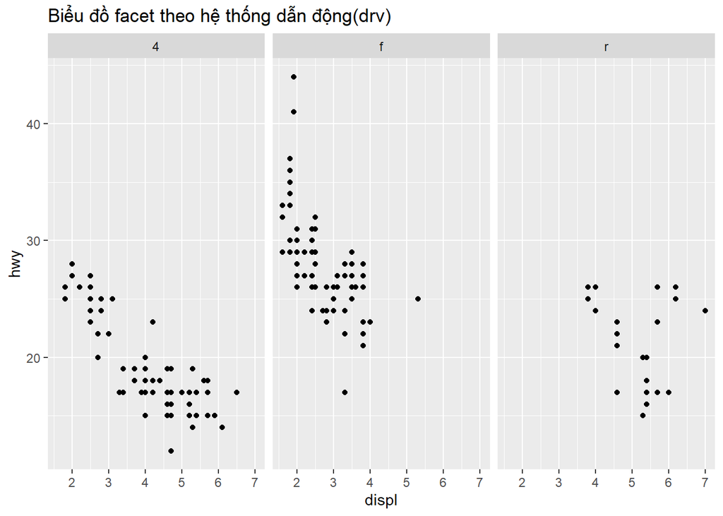

```r
ggplot(mpg, aes(x=displ, y=hwy))+
  geom_point()+
  facet_wrap(~drv)+
  labs(
    title="Biểu đồ facet theo hệ thống dẫn động(drv)",
    x="displ",
    y="hwy"
  )
```